| title: “Proyecto Estadística” |
| --- |
| author: Joshua Alexander Cobos Valle, Michael Anthony Castro Empuño, Kenneth Jair Saa Tomala, Armando Javier Moreira Salvatierra |
| date: “” |
| output: |
| html_document: |
| toc: yes |
| toc_depth: 2 |
| word_document: |
| toc: yes |
| toc_depth: ‘2’ |
| pdf_document: |
| toc: yes |
| toc_depth: 2 |
| csl: apa.csl |
| linkcolor: blue |
| urlcolor: blue |
| subtitle: Estudio de relación entre calidad de vida del estudiante y su rendimiento |
| académico |
| lang: es-ES |

# 1. Introducción

## 1.1 Objetivo General

Hallar la variable que más se ajuste al comportamiento de los promedios de los estudiante

## 1.2 Objetivos Específicos

# 2. Variables de estudio

## 2.1 Variables Cualitativas

- Sexo
- Realiza actividad física
- Cantidad de materias promedio por término
- Comidas diarias

## 2.2 Variables Cuantitativas

# 3. Estadística univariante descriptiva

Extracción de datos

```r
data <- read.csv(url("https://raw.githubusercontent.com/ArmandoMoreiraS/Estadistica/patch-1/Base2DatosEstudiantes.csv"),encoding = "UTF-8")


knitr::opts_chunk$set(echo = TRUE)
```

[output not shown]

## Sexo

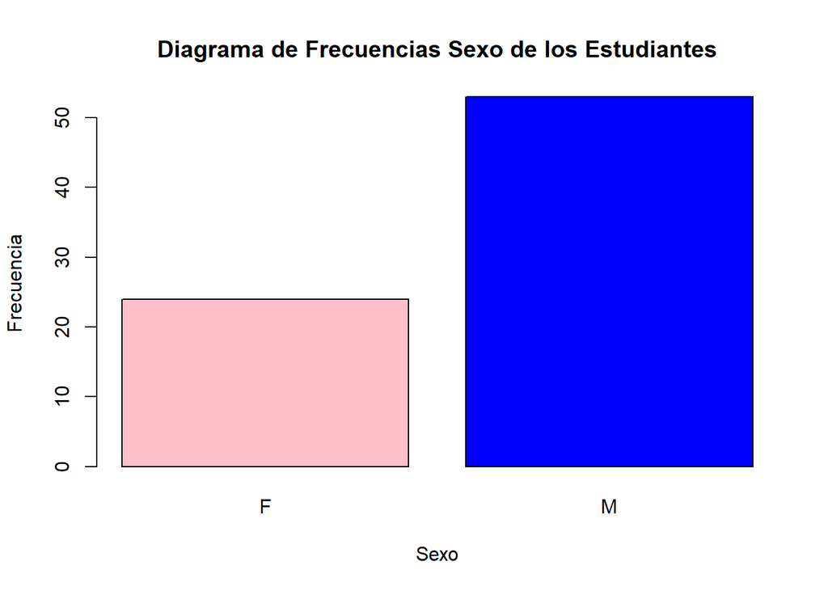

```r
x <- table (data$Sexo)
barplot(x, xlab = "Sexo", ylab = "Frecuencia", col = c("pink","blue"), main = "Diagrama de Frecuencias Sexo de los Estudiantes")
```

## Actividad física

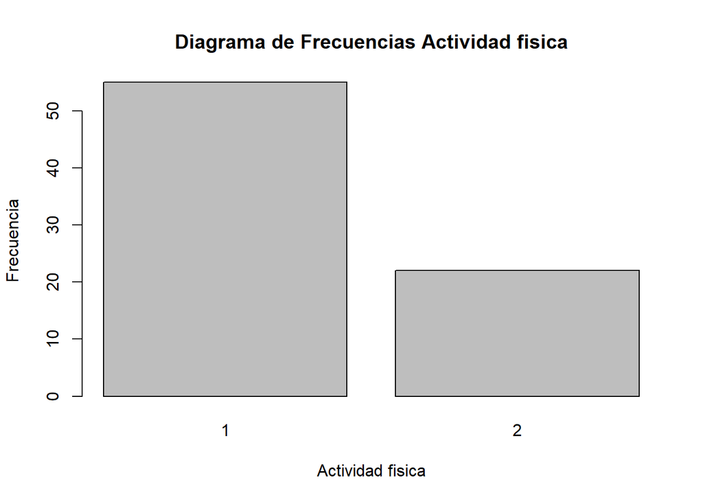

```r
actFisica <- data$Realiza_ejercicio
x <- table (data$Realiza_ejercicio)
barplot(x, xlab = "Actividad fisica", ylab = "Frecuencia", main = "Diagrama de Frecuencias Actividad fisica")
```

## Cantidad de materias promedio por término

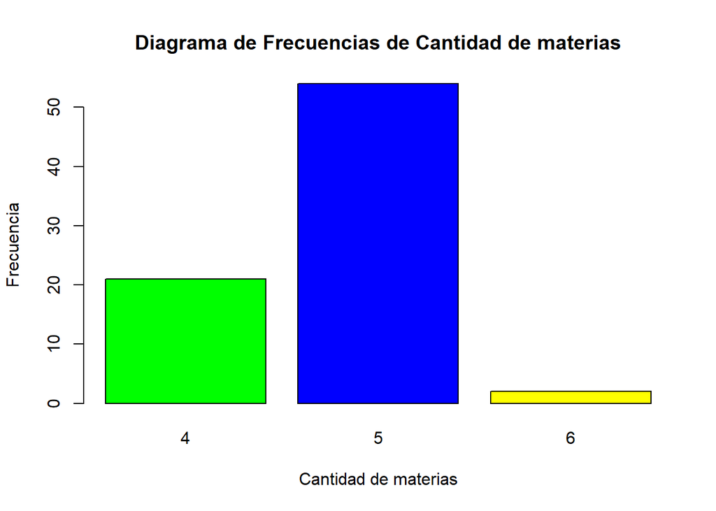

```r
cantMaterias <- data$Materias_Promedio_x_Termino
x <- table (data$Materias_Promedio_x_Termino)
barplot(x, xlab = "Cantidad de materias", ylab = "Frecuencia", col = c("green","blue","yellow"), main = "Diagrama de Frecuencias de Cantidad de materias")
```

## Comidas diarias

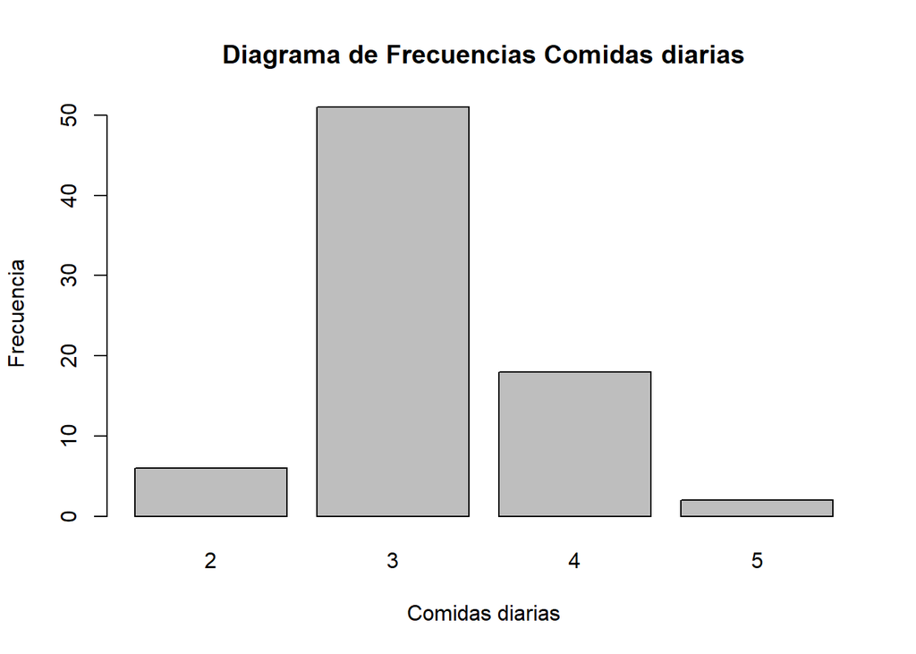

```r
x <- table (data$Numero_comidas_diarias)
barplot(x, xlab = "Comidas diarias", ylab = "Frecuencia", main = "Diagrama de Frecuencias Comidas diarias")
```

## Promedio

```r
library(moments)
library(fdth)
```

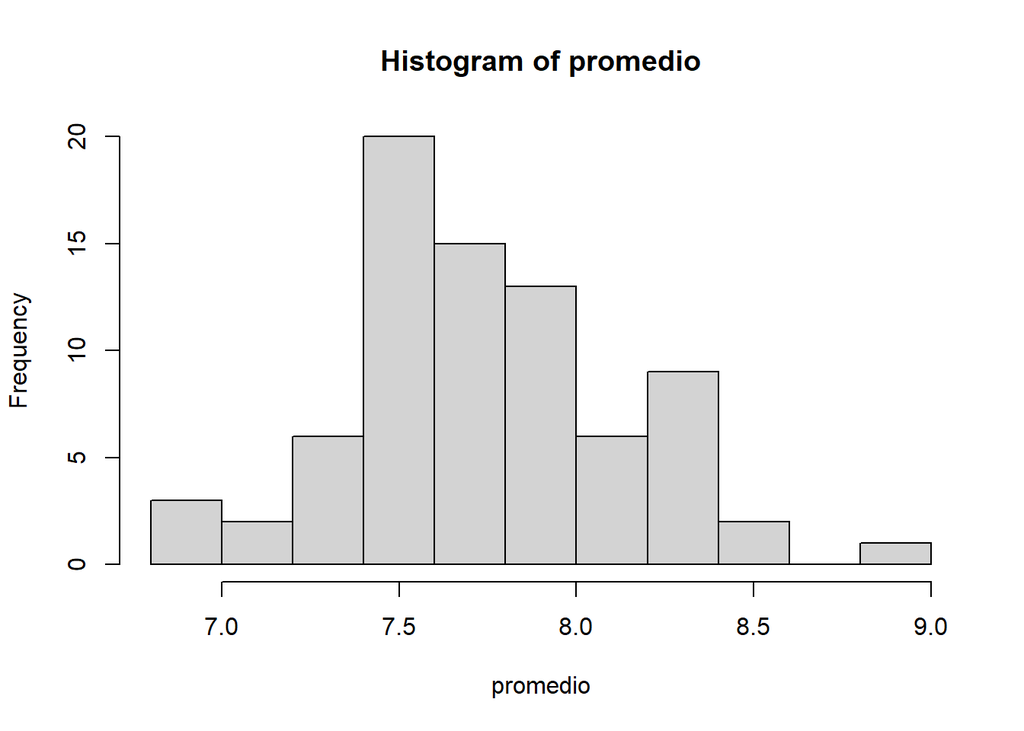

```r
promedio <- data$Promedio
hist(promedio)
```

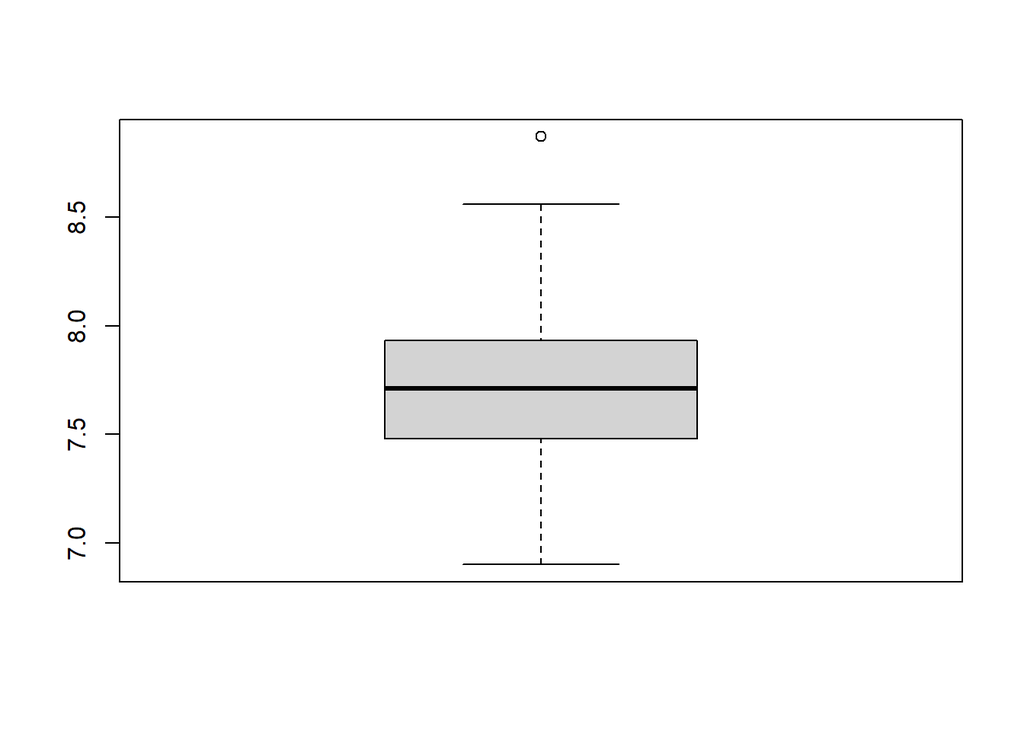

```r
boxplot(promedio)
```

```r
sd(promedio)
```

```
## [1] 0.3883425
```

```r
quantile(promedio,0.25)
```

```
##  25%
## 7.48
```

```r
quantile(promedio,0.75)
```

```
##  75%
## 7.93
```

```r
tb1=data.frame(mean(promedio),median(promedio),median(promedio),sd(promedio),quantile(promedio,0.25),quantile(promedio,0.75))
tb1 =(tb1)
View(tb1)
summary(data$Promedio)
```

```
##    Min. 1st Qu.  Median    Mean 3rd Qu.    Max.
##   6.900   7.480   7.710   7.746   7.930   8.870
```

```r
kurtosis(data$Promedio)
```

```
## [1] 3.115172
```

```r
skewness(data$Promedio)
```

```
## [1] 0.3378607
```

```r
promedio1 <- fdt(data$Promedio,breaks=c('Sturges'),right=FALSE,na.rm=FALSE)
promedio_table <- promedio1$table
```

## Carbohidratos por comida

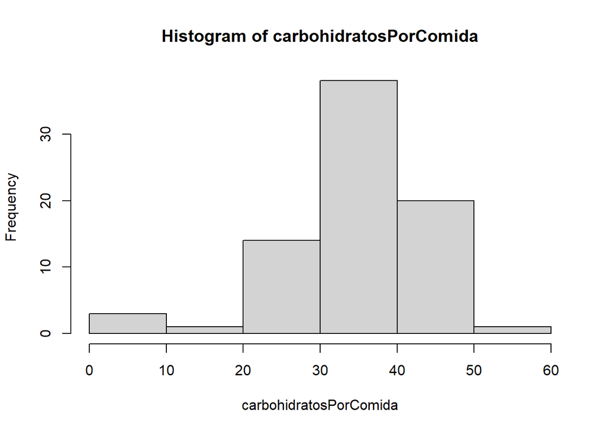

```r
carbohidratosPorComida <- data$Porcentaje_promedio_carbohidrato_por_comida
hist(carbohidratosPorComida)
```

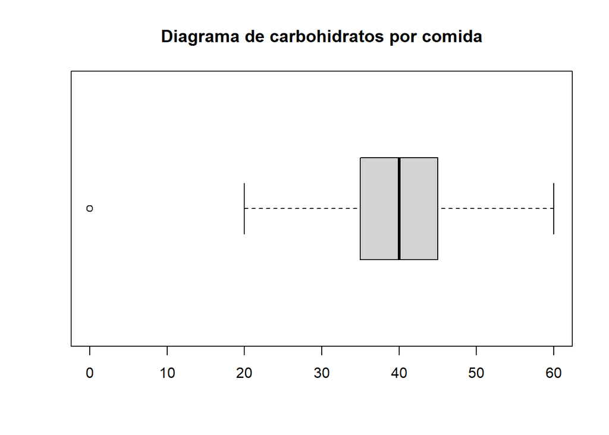

```r
boxplot(data$Porcentaje_promedio_carbohidrato_por_comida,horizontal = T,main="Diagrama de carbohidratos por comida")
```

```r
tb2=data.frame(mean(carbohidratosPorComida),median(carbohidratosPorComida),median(carbohidratosPorComida),sd(carbohidratosPorComida),quantile(carbohidratosPorComida,0.25),quantile(carbohidratosPorComida,0.75))
summary(carbohidratosPorComida)
```

```
##    Min. 1st Qu.  Median    Mean 3rd Qu.    Max.
##    0.00   35.00   40.00   38.57   45.00   60.00
```

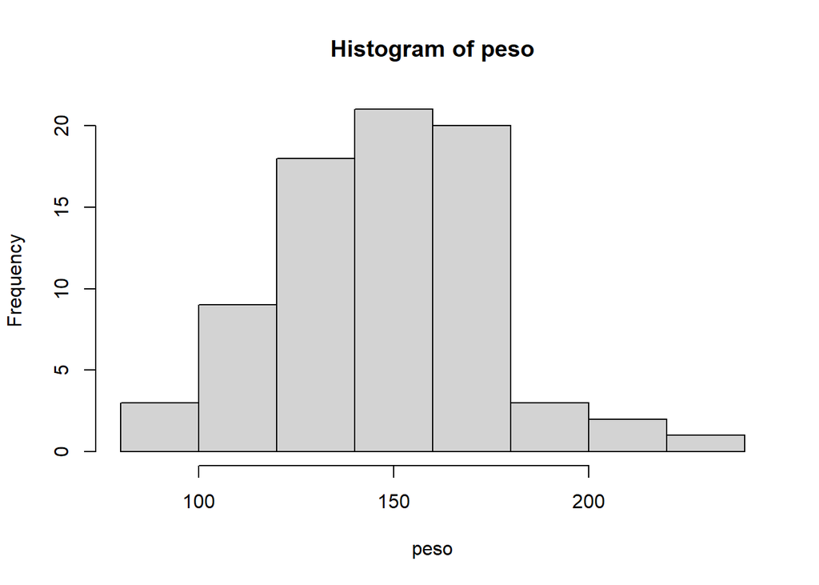

```r
peso <- data$Peso
hist(peso)
```

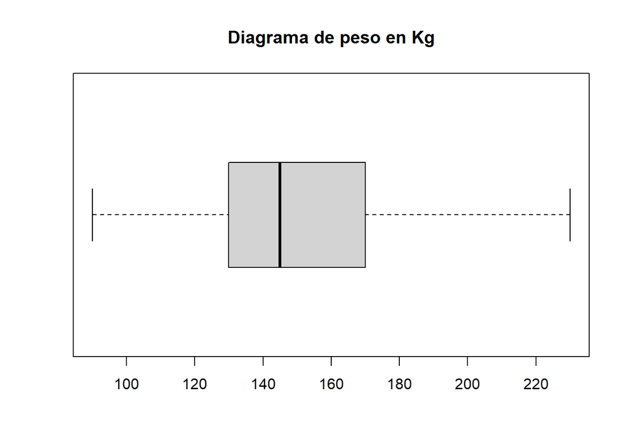

```r
boxplot(data$Peso,horizontal = T,main="Diagrama de peso en Kg")
```

```r
tb4=data.frame(mean(peso),median(peso),median(peso),sd(peso),quantile(peso,0.25),quantile(peso,0.75))
tb4
```

```
##     mean.peso. median.peso. median.peso..1 sd.peso. quantile.peso..0.25.
## 25%   149.7247          145            145 28.21648                  130
##     quantile.peso..0.75.
## 25%                  170
```

## Cantidad de horas de sueño

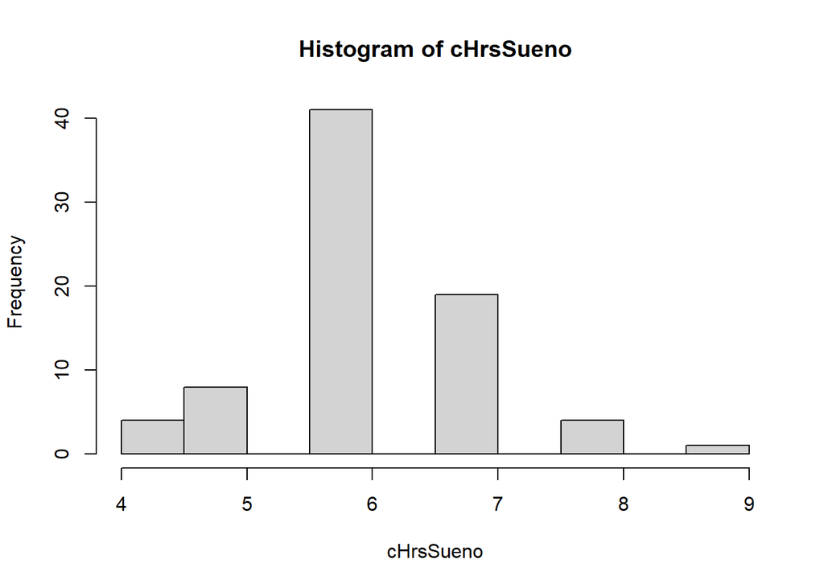

```r
cHrsSueno <- data$Horas_promedio_diarias_sueño
hist(cHrsSueno)
```

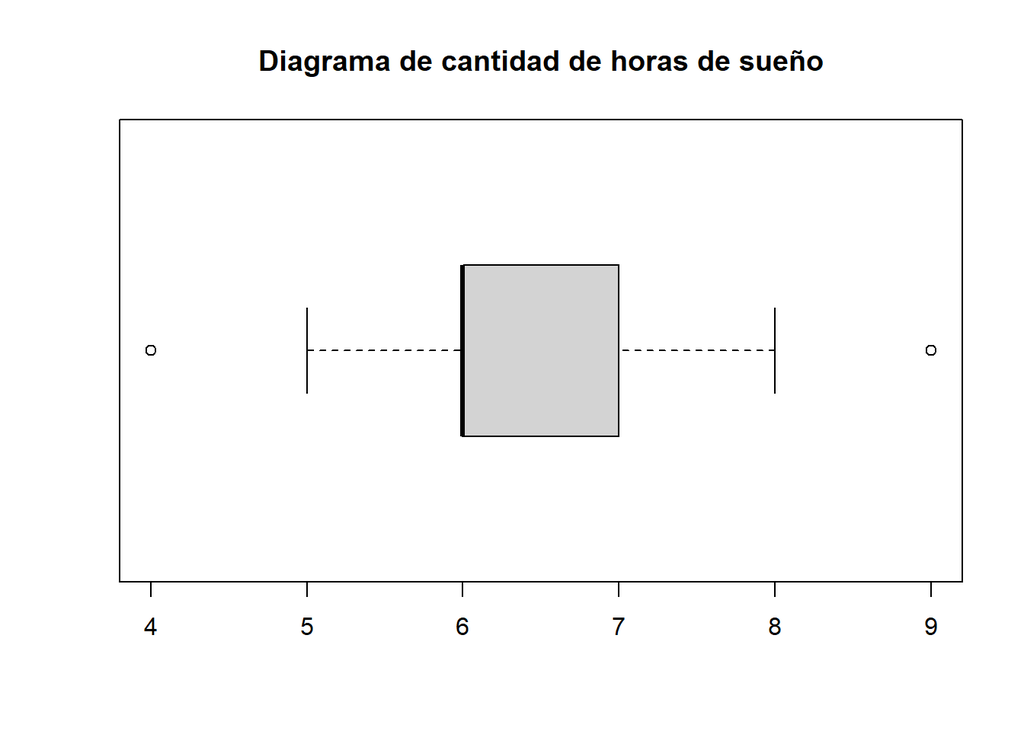

```r
boxplot(data$Horas_promedio_diarias_sueño,horizontal = T,main="Diagrama de cantidad de horas de sueño")
```

## Consumo de agua promedio semanal en litros

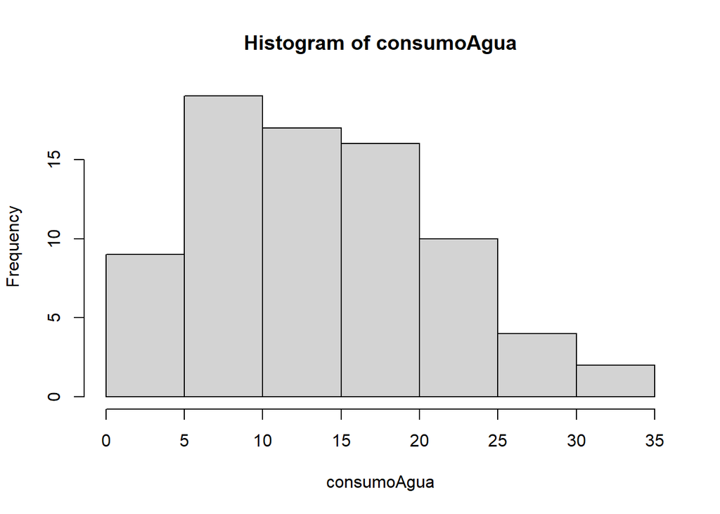

```r
consumoAgua <- data$Consumo_promedio_semanal_agua
hist(consumoAgua)
```

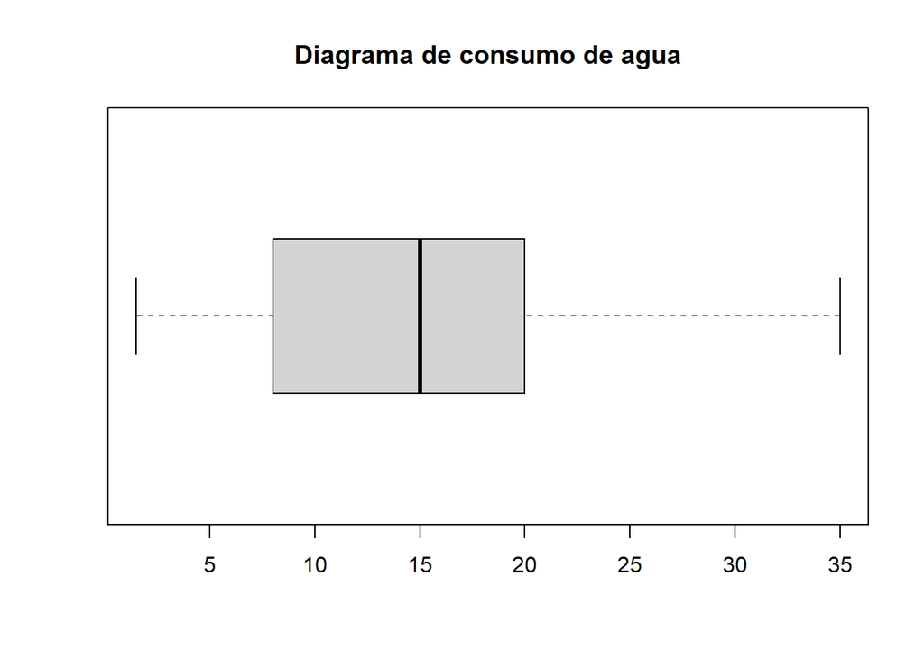

```r
boxplot(data$Consumo_promedio_semanal_agua,horizontal = T,main="Diagrama de consumo de agua")
```

```r
tb5=data.frame(mean(consumoAgua),median(consumoAgua),median(consumoAgua),sd(consumoAgua),quantile(consumoAgua,0.25),quantile(consumoAgua,0.75))
```

# 4. Estadística bivariante

Comparación de promedios por sexo mediante diagrama de caja

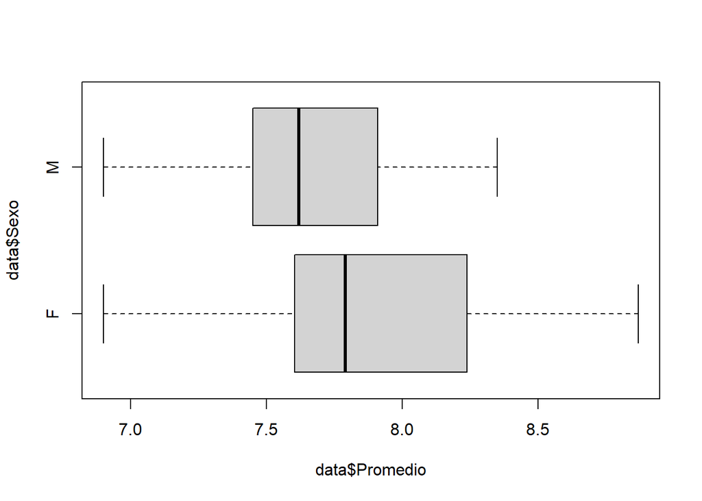

```r
boxplot(data$Promedio ~ data$Sexo, title = "Comparación de promedio por sexo", horizontal=T)
```

Comparación de promedios por actividad física mediante diagrama de cajas

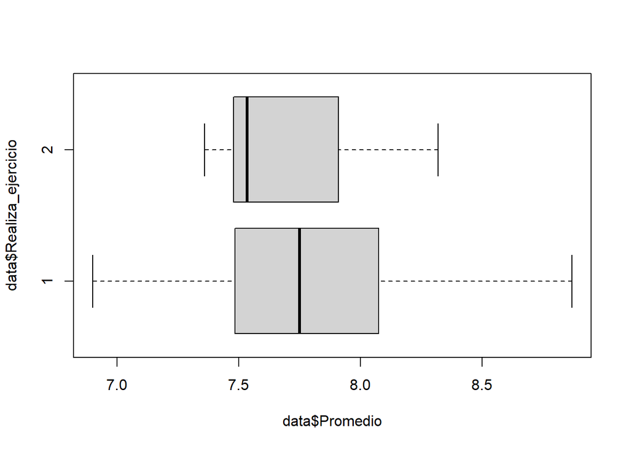

```r
boxplot(data$Promedio ~ data$Realiza_ejercicio, horizontal=T)
```

Comparación de promedios por cantidad de materias mediante diagrama de cajas

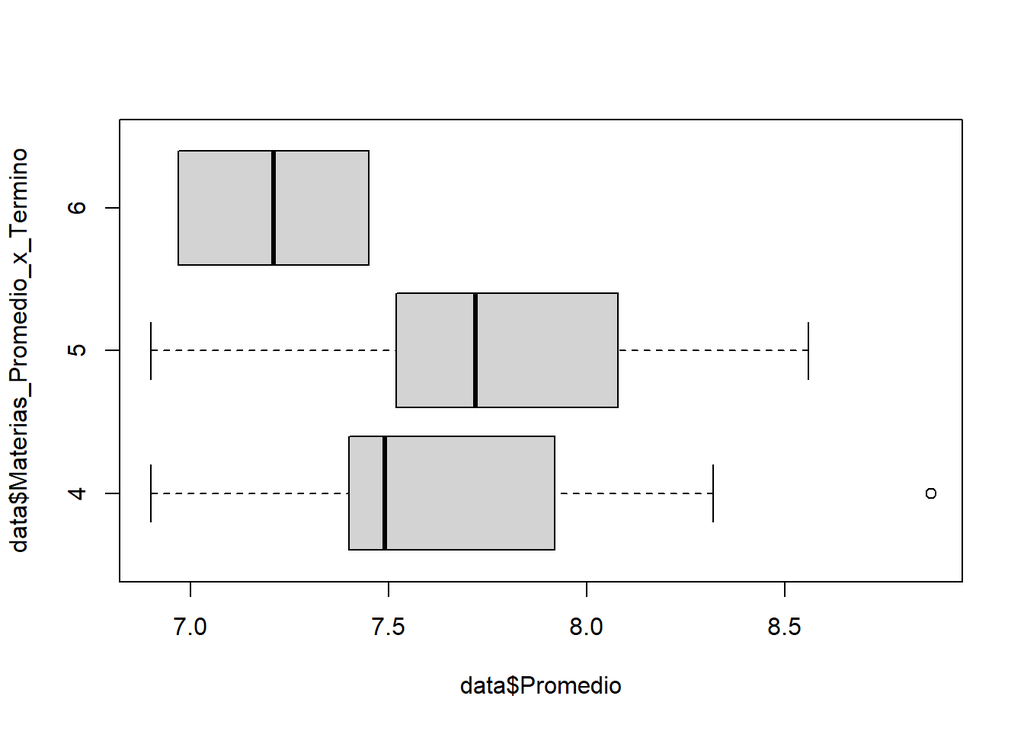

```r
boxplot(data$Promedio ~ data$Materias_Promedio_x_Termino, horizontal=T)
```

Comparación de promedios por comidas diarias mediante diagrama de cajas

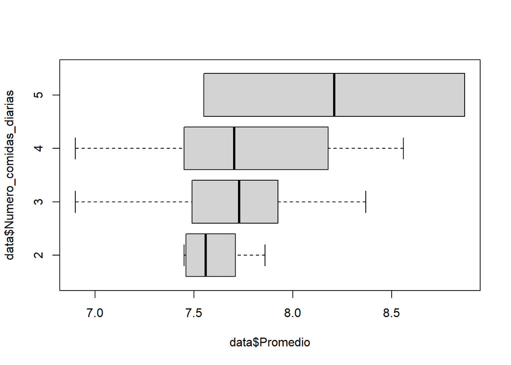

```r
boxplot(data$Promedio ~ data$Numero_comidas_diarias, horizontal=T)
```

Matriz de correlación Promedio y Carbohidratos por comida

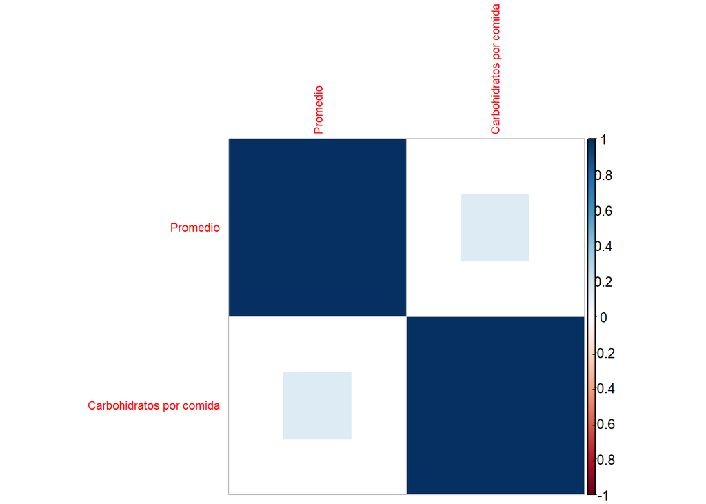

```r
library(corrplot)
dtPromedio_Carbohidratos <- data.frame(data$Promedio,data$Porcentaje_promedio_carbohidrato_por_comida)
colnames(dtPromedio_Carbohidratos) <- c("Promedio","Carbohidratos por comida")
corrplot(cor(dtPromedio_Carbohidratos),method = 'square',tl.cex = 0.7)
```

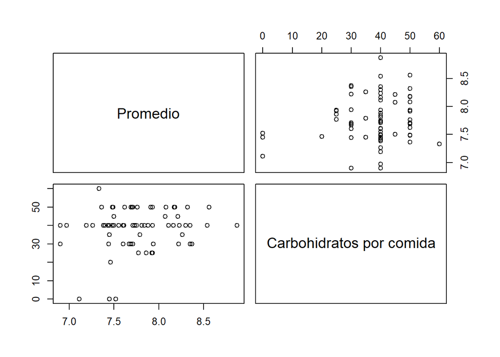

```r
pairs(dtPromedio_Carbohidratos)
```

Matriz de correlación Promedio y Peso

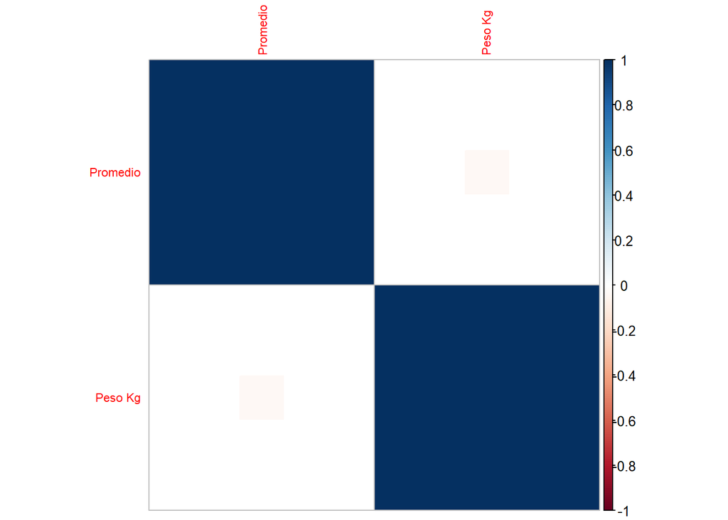

```r
library(corrplot)
dtPromedio_Peso <- data.frame(data$Promedio,data$Peso)
colnames(dtPromedio_Peso) <- c("Promedio","Peso Kg")
corrplot(cor(dtPromedio_Peso),method = 'square',tl.cex = 0.7)
```

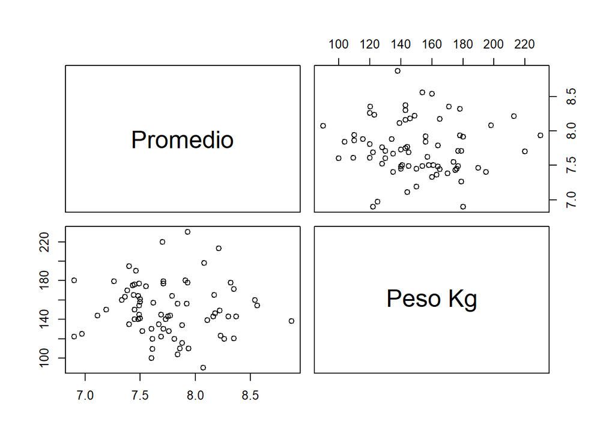

```r
pairs(dtPromedio_Peso)
```

Matriz de correlación Promedio y Horas de sueño

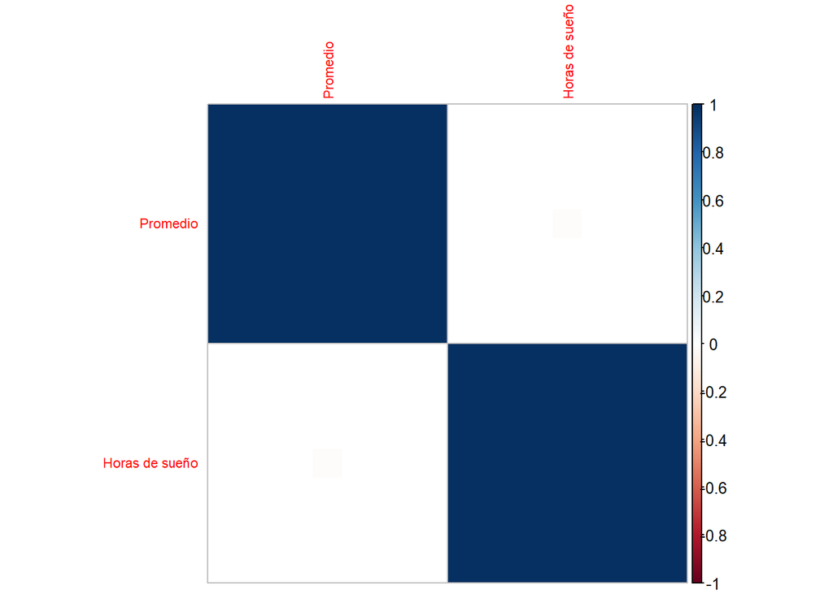

```r
library(corrplot)
dtPromedio_Sueno <- data.frame(data$Promedio,data$Horas_promedio_diarias_sueño)
colnames(dtPromedio_Sueno) <- c("Promedio","Horas de sueño")
corrplot(cor(dtPromedio_Sueno),method = 'square',tl.cex = 0.7)
```